# Taipei accident analysis

## 概論

我們在**臺北市資料大平台**裡，找到一份有趣的資料——「交通事故資訊」，於是想從這份資料，探究*什麼樣的人比較容易發生交通事故(who)*、*什麼的時段比較容易發生交通事故(when)*以及*什麼區域最容易發生交通事故(where)*等三個問題。

## 資料介紹

此資料來自**臺北市資料大平台**，以「107年-臺北市A1及A2類交通事故明細.csv」此資料為主要分析，裡面的column有「發生年、發生月、發生日、發生時 發生分、處理別、區序、肇事地點、死亡人數、受傷人數、當事人序、車種、性別、年齡、受傷程度、天候、速限、道路型態以及事故位置」，而總資料數有50330筆。

次資料來自於網路上的「台灣街道、道路路名」，裡頭提供我所需要的全臺北市各區域的路名，並將之匯入字典，以方便jieba系統斷詞。

[臺北市交通事故](https://data.taipei/#/dataset/detail?id=2f238b4f-1b27-4085-93e9-d684ef0e2735)

[台灣街道、道路路名表 SQL資料下載](http://blog.davidou.org/archives/583)

## 其他同學html連結

楊岳錩 [性別分析](https://cinnyhu.github.io/Class/Week3/wwww.html)

胡煜欣 [時間分析](https://cinnyhu.github.io/Class/Week3/wwww.html)

##code介紹

part1

1.匯入需要的library

```r
# map
library(GISTools)
library(rgdal)
library(sp)
# data
library(dplyr)
# plot
library(ggplot2)
```

2.讀取地圖檔(.shp)，並選擇臺北市的資料，特別取出Data部分研究

```r
TW <- readOGR(dsn = ".", layer = "TOWN_MOI_1080617", use_iconv = TRUE,encoding="UTF-8") # 台灣村里界 (面資料)
TP <- subset(TW, COUNTYNAME== "臺北市")
taipei<-TP@data
str(taipei)
```

```
## 'data.frame':    12 obs. of  7 variables:
##  $ TOWNID    : Factor w/ 368 levels "A01","A02","A03",..: 2 7 12 4 3 8 1 5 6 9 ...
##  $ TOWNCODE  : Factor w/ 368 levels "09007010","09007020",..: 213 218 212 217 215 219 211 216 214 220 ...
##  $ COUNTYNAME: Factor w/ 22 levels "宜蘭縣","花蓮縣",..: 19 19 19 19 19 19 19 19 19 19 ...
##  $ TOWNNAME  : Factor w/ 357 levels "七股區","七美鄉",..: 27 71 192 300 46 203 168 25 45 63 ...
##  $ TOWNENG   : Factor w/ 353 levels "Alian District",..: 33 270 299 266 340 173 240 49 338 181 ...
##  $ COUNTYID  : Factor w/ 22 levels "A","B","C","D",..: 1 1 1 1 1 1 1 1 1 1 ...
##  $ COUNTYCODE: Factor w/ 22 levels "09007","09020",..: 17 17 17 17 17 17 17 17 17 17 ...
```

3.讀取臺北市交通事故的資料，並重新命名column name

```r
accident<-read.csv("C:\\Users\\user\\Desktop\\TR.csv")
names(accident)<-c('year','month','date','hour','minute','incident','district','location','death','injured','order','type','sex','age','degree','weather','rate','road','accident_type')
accident$district<-gsub("[0-9]", "", accident$district)
```

4.算個臺北市各區域的交通事故數量，並將之合併於taipei裡

```r
freq<-count(accident,district)
freq<-freq[order(freq$district),]
taipei<-taipei[order(taipei$TOWNNAME),]
taipei$freq<-freq$n
```

5.重新編排taipei的row number,使得對應原資料不會有錯誤

*算出每平方公里交通事故量*

```r
taipei<-taipei[order(as.numeric(rownames(taipei))),,drop=FALSE]
taipei$AREA <- poly.areas(TP)/ 10^6
taipei$density<-taipei$freq/taipei$AREA
```

6.畫各縣市區域交通事故總計

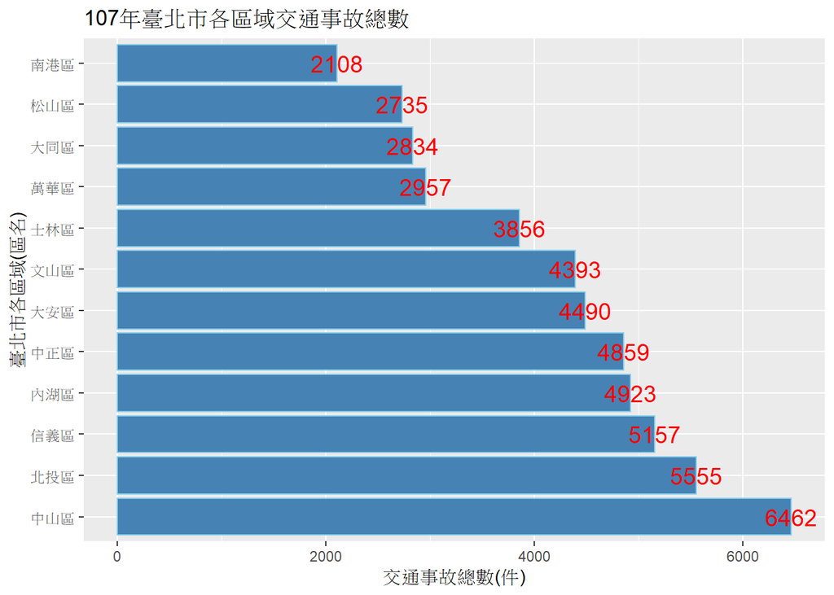

```r
taipei2<-taipei[order(taipei$freq),]
ggplot(taipei2,aes(x=reorder(TOWNNAME,-freq),y=freq))+geom_bar(stat='identity',color='skyblue',fill='steelblue')+
  coord_flip()+ggtitle('107年臺北市各區域交通事故總數')+geom_text( aes(label =freq), color=('red'), size = 5)+
  labs(y="交通事故總數(件)", x ="臺北市各區域(區名)" )
```

7.畫地圖1

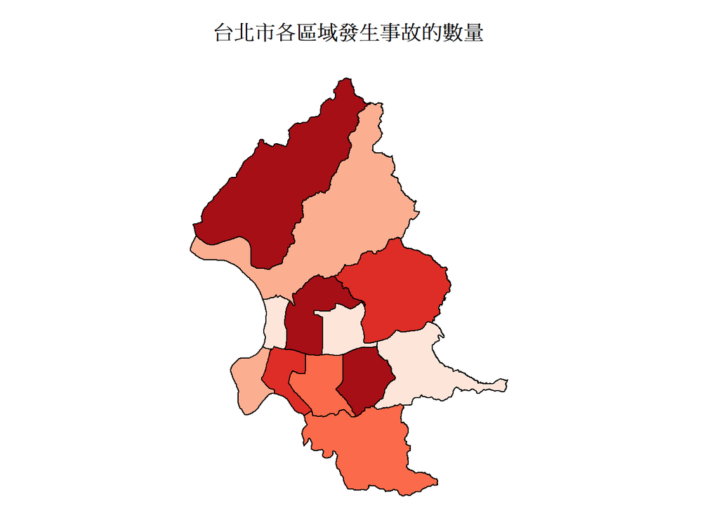

```r
par(mar = c(0,0,3,1))
shades <- auto.shading(taipei$freq, cutter = quantileCuts,n =5, cols = brewer.pal(5, "Reds"))
choropleth(TP,taipei$freq, shading=shades,cex=10)
title('台北市各區域發生事故的數量')
```

8.畫地圖2

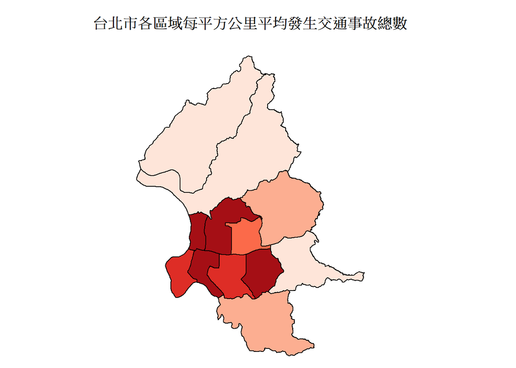

```r
par(mar = c(0,0,3,1))
shades <- auto.shading(taipei$density, cutter = quantileCuts,n =5, cols = brewer.pal(5, "Reds"))
choropleth(TP,taipei$density, shading=shades,cex=10)
title('台北市各區域每平方公里平均發生交通事故總數')
```

par2 從地址找關鍵路段

1.將需要的library匯入

```r
library(jiebaR)
library(jiebaRD)
```

2.設計function

```r
get_path<-function(alldistrict){
  path<-paste0("C:\\Users\\user\\Desktop\\district\\",alldistrict,'.txt')
  path
}
read_text<-function(path){
  word<-readLines(path, encoding = "UTF-8")
  word<-unlist(strsplit(word,','))
  word<-gsub("１", "1", word)
  word<-gsub("２", "2", word)
  word<-gsub("３", "3", word)
  word<-gsub("４", "4", word)
  word
}
cutword<-function(road){
  for(x in 1:length(road)){
    new_user_word(cutter,road[x],'n')
  }
}
add_dist<-function(district){
  new_user_word(cutter,district,'n')
}
getword<-function(eachdistrict){
  w<-filter(accident,district==eachdistrict)
  countw<-cutter[as.character(w$location)]
  countw<-gsub('口','',countw)
  countw<-gsub('與','',countw)
  countw<-gsub('號','',countw)
  countw<-gsub('巷','',countw)
  countw<-gsub('弄','',countw)
  countw
}
```

3.得到最後每個區域被切割過文字的地址

```r
allpath<-lapply(taipei$TOWNENG,get_path)
road<-lapply(allpath, read_text)
cutter<-worker()
lapply(road,cutword)
```

```r
lapply(as.character(taipei$TOWNNAME),add_dist)
```

```
## [[1]]
## [1] TRUE
##
## [[2]]
## [1] TRUE
##
## [[3]]
## [1] TRUE
##
## [[4]]
## [1] TRUE
##
## [[5]]
## [1] TRUE
##
## [[6]]
## [1] TRUE
##
## [[7]]
## [1] TRUE
##
## [[8]]
## [1] TRUE
##
## [[9]]
## [1] TRUE
##
## [[10]]
## [1] TRUE
##
## [[11]]
## [1] TRUE
##
## [[12]]
## [1] TRUE
```

```r
all<-lapply(as.character(taipei$TOWNNAME), getword)
```

4.以「北投區」為例，畫出文字雲

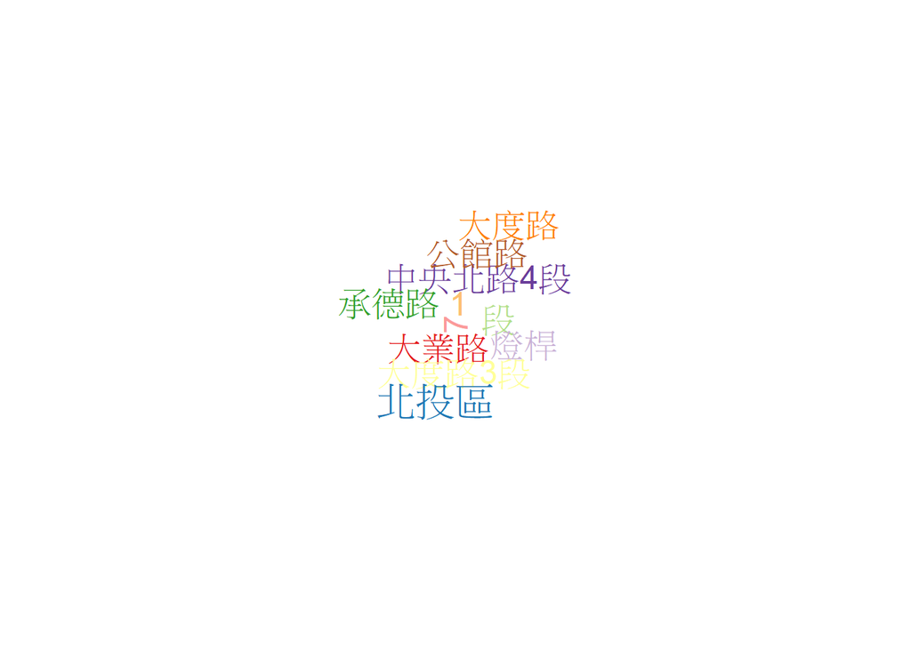

```r
sortw<-freq(all[[12]])
sortw=sortw[order(sortw$freq,decreasing=T),]
library(wordcloud)
wordcloud(words=sortw$char[1:12],freq=sortw$freq[1:12],scale = c(2,1.5), # 給定文字尺寸的區間（向量）
          ordered.colors = T,#關閉配色順序
          min.freq = 10,# 定義最小freq數字
          colors = brewer.pal(12,"Paired")
)
```